# Nass Data Preparation

November 08, 2019

Some analysis and manipulation is required to prepare data for input to the timber supply model. This report documents the work flow completed.

The constraint input files were built in a table `tsa43_dataprep`. The starting table was created from the `tsa43_netdown` so that area checks using CFLB and THLB could be run.

The RasterTools will then be applied to export data from this table into .tif raster files for use in SELES. The ‘cats’ file generated during this process can be used to create the constraints text file.

```sql
drop table if exists tsa43_dataprep;

create table tsa43_dataprep as (
  select
    skey.gr_skey,
    net.cflb_fact,
    net.thlb_fact,
    skey.wkb_geometry
  from tsa43_skey skey
  left join tsa43_netdown net
  on skey.gr_skey = net.gr_skey
  where skey.gr_skey > 0
);
```

# 1 Visual Quality Objectives

Summarize the area in visuals by VAC and VQO. I checked to make sure that only the visuals “made known” = “Y” had VQO assigned. So all other VLI polys can be ignored.

```r
dbGetQuery(db,'
  select  vli_evqo, vli_vac, count(gr_skey) total
  from tsa43_res
  where vli_evqo is not null
  group by 1,2 order by 1,2;
') %>%
#transpose
spread(vli_vac, total) %>%
#add a totals row
bind_rows(
  #sum all numeric columns
  summarise_if(., is.numeric, sum, na.rm=T) %>%
  #add row title to sums
  mutate(vli_evqo="Total")
) %>%
#choose columns and retitle
select(VQO=vli_evqo, Low=L, Medium=M, High=H) %>%
#format table
kable() %>%
  row_spec(5, bold=T)  %>%
  add_header_above(c(" ", "VAC" = 3))
```

| VQO | VAC Low | VAC Medium | VAC High |
| --- | --- | --- | --- |
| M | 12,263 | 18,117 | 2,541 |
| P | 2,355 | 6,728 | 2,777 |
| PR | 14,298 | 17,195 | 751 |
| R | 5,209 | 16,143 |  |
| Total | 34,125 | 58,183 | 6,069 |

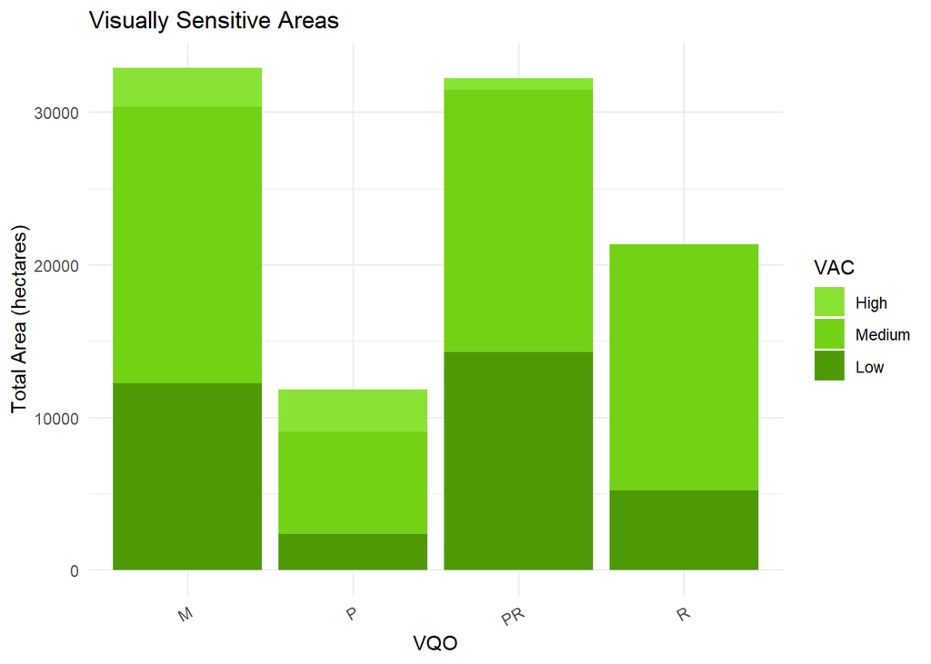

```r
dbGetQuery(db,'
  select vli_evqo, vli_vac, count(gr_skey) total
  from tsa43_res
  where vli_evqo is not null
  group by 1,2 order by 1,2;
') %>%
  #reorder the landbase for the graph
  mutate(
    vli_vac = vli_vac %>% fct_relevel('H', 'M', 'L'),
  ) %>%
  #plot bar graph
  ggplot(aes(vli_evqo, total, fill=vli_vac)) +
    geom_bar(stat="identity") +
    scale_fill_manual(values = c('#8ae234', '#73d216', '#4e9a06'),
    name = "VAC",
    labels = c("High", "Medium", "Low")) +
    ggtitle("Visually Sensitive Areas") +
    xlab("VQO") +
    ylab("Total Area (hectares)") +
    gg_theme
```

## 1.1 Visual Constraints

**Data Package Section 6.3.7**

- There are 349 unique polygons but vli_poly is not numbered sequentially
- vli_vsu_number is all NULL
- Only 90 visual polygons are made known

The vli_poly will be used to identify the constraint population. A concatenate of vli_vac and and vli_evqo will be used to indentify the constraints to apply. An underscore is used to separate the attributes.

```sql
alter table tsa43_dataprep
  add column vli_poly numeric,
  add column vli_target text;
```

```sql
update tsa43_dataprep dp set
  vli_poly = res.vli_poly,
  vli_target = concat_ws('_', res.vli_vac, res.vli_evqo)
from tsa43_res res
where
  vli_made_known = 'Y'
  and dp.gr_skey = res.gr_skey;
```

- There are 11 unique combinations of vli_target within the made known visual polygons

```r
dbGetQuery(db,'
  select vli_target, sum(cflb_fact) cflb, sum(cflb_fact*thlb_fact) thlb
  from tsa43_dataprep
  where vli_target is not null
  group by 1 order by 1;
') %>%
bind_rows(summarise_if(., is.numeric, sum, na.rm=T)) %>%
kable() %>%
  row_spec(12, bold=T)
```

| vli_target | cflb | thlb |
| --- | --- | --- |
| H_M | 2,206 | 976 |
| H_P | 964 | 352 |
| H_PR | 511 | 17 |
| L_M | 9,078 | 6,670 |
| L_P | 922 | 242 |
| L_PR | 10,473 | 7,305 |
| L_R | 878 | 212 |
| M_M | 13,273 | 7,910 |
| M_P | 468 | 93 |
| M_PR | 10,607 | 5,116 |
| M_R | 6,857 | 3,832 |
|  | 56,237 | 32,725 |

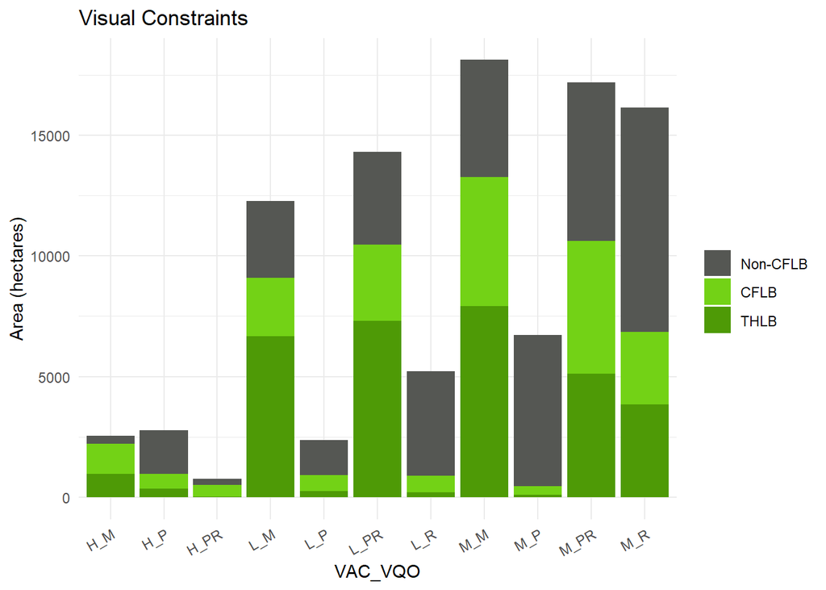

```r
dbGetQuery(db,'
  select
    vli_target, sum(1-cflb_fact) nonfor,
    sum(cflb_fact-(cflb_fact*thlb_fact)) nonthlb, sum(cflb_fact*thlb_fact) thlb
  from tsa43_dataprep
  where vli_target is not null
  group by 1 order by 1;
') %>%
  #gather the cflb and nonfor areas into one column
  gather(nonfor, nonthlb, thlb, key = 'landbase', value = 'area') %>%
  #reorder the landbase for the graph
  mutate(
    landbase = landbase %>% fct_relevel('nonfor', 'nonthlb', 'thlb'),
  ) %>%
  #plot bar graph
  ggplot(aes(vli_target, area, fill=landbase)) +
    geom_bar(stat="identity") +
    scale_fill_manual(values = c('#555753', '#73d216', '#4e9a06'),
    name = '',
    labels = c('Non-CFLB', 'CFLB', 'THLB') ) +
    ggtitle("Visual Constraints") +
    xlab("VAC_VQO") +
    ylab("Area (hectares)") +
    gg_theme
```

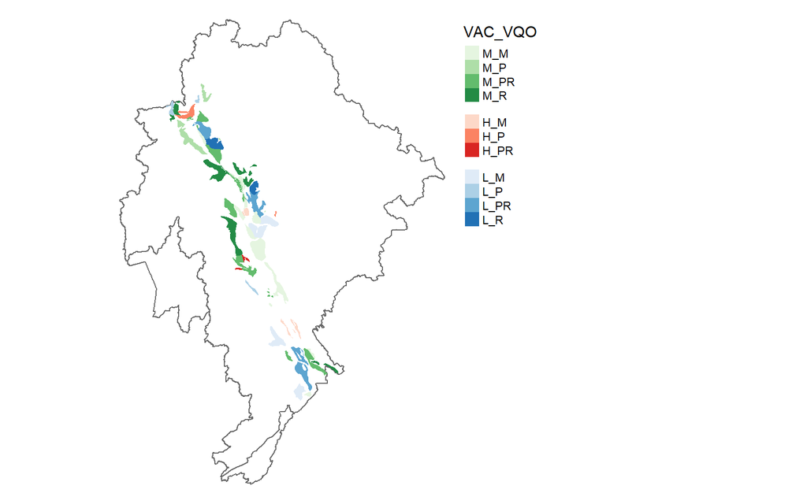

```r
vliMapData <- st_read(db, query='
  select vli_target, st_union(wkb_geometry)
  from tsa43_dataprep
  where vli_target is not null
  group by 1 order by 1;
')

bnd +
tm_shape(vliMapData %>% filter(str_sub(vli_target,1,1)=='M')) +
  tm_fill(col='vli_target', palette = 'Greens', title = 'VAC_VQO') +
tm_shape(vliMapData %>% filter(str_sub(vli_target,1,1)=='H')) +
  tm_fill(col='vli_target', palette = 'Reds', title = '') +
tm_shape(vliMapData %>% filter(str_sub(vli_target,1,1)=='L')) +
  tm_fill(col='vli_target', palette = 'Blues', title = '') +
tm_layout(frame = FALSE, legend.outside = TRUE)
```

# 2 Disturbance Outside the THLB

**Data Package Section 5.14.4**

Calculate the periodic area to be disturbed. Query data to fill in spreadsheet `BECInfo.xlsx`.

```r
dbGetQuery(db,'
  select
    substr(res.bgc_label,1,4) bgc_label, bec_ndt,
    sum(net.cflb_fact-(net.cflb_fact*net.thlb_fact)) cflb
  from tsa43_res res
  left join tsa43_netdown net
  on res.gr_skey = net.gr_skey
  where net.cflb_fact > 0
  group by 1,2 order by 1,2;
') %>%
  spread(bec_ndt, cflb) %>%
  bind_rows(
    summarise_if(., is.numeric, sum, na.rm=T) %>%
    mutate(bgc_label = 'Total')
  ) %>%
  select('BEC Label' = bgc_label, NDT1, NDT2, NDT3, NDT5) %>%
  kable() %>%
    row_spec(7, bold=T)  %>%
    add_header_above(c(" ", "Natural Disturbance Type" = 4))
```

| BEC Label | Natural Disturbance Type NDT1 | Natural Disturbance Type NDT2 | Natural Disturbance Type NDT3 | Natural Disturbance Type NDT5 |
| --- | --- | --- | --- | --- |
| CMA |  |  |  | 46 |
| CWH | 5,156 | 4,936 |  |  |
| ESSF | 93,422 |  | 18,453 | 2,420 |
| ICH | 62,647 | 98,525 |  |  |
| MH | 31,175 |  |  | 1,407 |
| SBS |  |  | 27,370 |  |
| Total | 192,400 | 103,461 | 45,823 | 3,873 |

# 3 Mixed Deciduous

**Data Package Section 6.1.3**

It is assumed that all deciduous within stands will be maintained perpetually within the SRMP area. A yield/area reduction factor to represent the existing deciduous was created based on totalling all the deciduous between secondary and senary species.

```sql
alter table tsa43_dataprep
  add column decid_fact numeric;
```

```sql
update tsa43_dataprep dp set decid_fact =
    case when res.spec_cd_2 in ('AC','ACT','AT','DR','E','EP') then res.spec_pct_2 else 0 end +
    case when res.spec_cd_3 in ('AC','ACT','AT','DR','E','EP') then res.spec_pct_3 else 0 end +
    case when res.spec_cd_4 in ('AC','ACT','AT','DR','E','EP') then res.spec_pct_4 else 0 end +
    case when res.spec_cd_5 in ('AC','ACT','AT','DR','E','EP') then res.spec_pct_5 else 0 end +
    case when res.spec_cd_6 in ('AC','ACT','AT','DR','E','EP') then res.spec_pct_6 else 0 end
from tsa43_res res
where res.rmp_strgc_name = 'Nass South Sustainable Resource Management Plan'
and dp.gr_skey = res.gr_skey;
```

The exported decid_fact will be used directly as VDYP_OAF in the SELES model.

- I was worried about this reduction being applied aspatially until I totalled the THLB impact
- Only an equivalent of 1,753 ha will be excluded due to this factor

```r
dbGetQuery(db,'
  select
    round(decid_fact/10.0)*10 decid_fact,
    sum(1-cflb_fact) nonfor, sum(cflb_fact-(cflb_fact*thlb_fact)) nonthlb,
    sum(cflb_fact*thlb_fact) thlb, sum(cflb_fact*thlb_fact*decid_fact/100.0) thlb_excl
  from tsa43_dataprep
  where decid_fact > 0
  group by 1 order by 1;
') %>%
bind_rows(
    summarise_if(., is.numeric, sum, na.rm=T) %>%
    mutate(decid_fact = NA)
) %>%
kable() %>%
    row_spec(8, bold=T)
```

| decid_fact | nonfor | nonthlb | thlb | thlb_excl |
| --- | --- | --- | --- | --- |
| 0 | 48 | 1,002 | 459 | 9 |
| 10 | 578 | 10,739 | 5,540 | 541 |
| 20 | 404 | 4,181 | 2,558 | 508 |
| 30 | 133 | 2,221 | 1,188 | 352 |
| 40 | 74 | 1,142 | 664 | 263 |
| 50 | 15 | 333 | 141 | 67 |
| 60 | 6 | 178 | 23 | 13 |
|  | 1,258 | 19,796 | 10,573 | 1,753 |

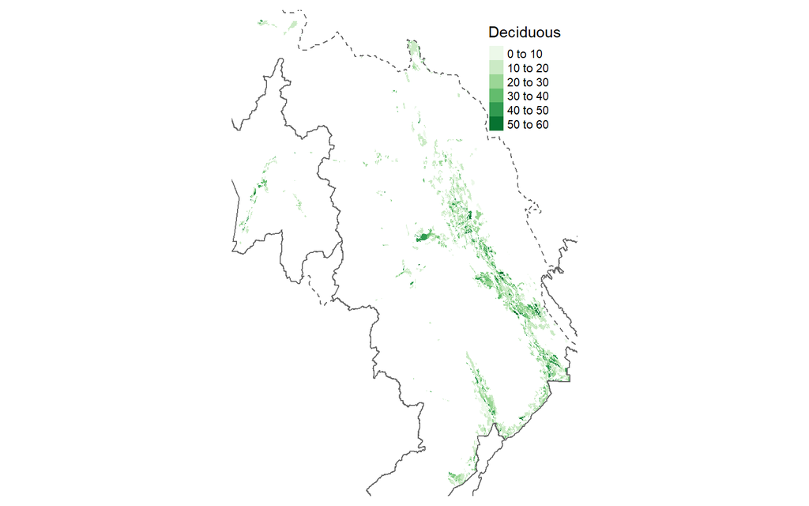

```r
decidMapData <- st_read(db, query='
  select round(decid_fact/10.0)*10 decid_fact, st_union(wkb_geometry)
  from tsa43_dataprep
  where decid_fact > 0
  group by 1;
')
tm_shape(decidMapData) +
  tm_fill('decid_fact', palette = 'Greens', title = 'Deciduous') +
  tm_layout(frame = FALSE, legend.position = c('right','top')) + srmp + bnd
```

# 4 Depletion

- The VRI `extract(year from hrvstdt)` matches the consolidated cutblocks harvest_year in all but 55 ha in the resultant
- Limited the residuals to only havesting that occurred after the photo interpretation reference year
- The total area requiring depletions (>10 years from age based on harvest_year) was 1186 ha CFLB, 976 ha THLB

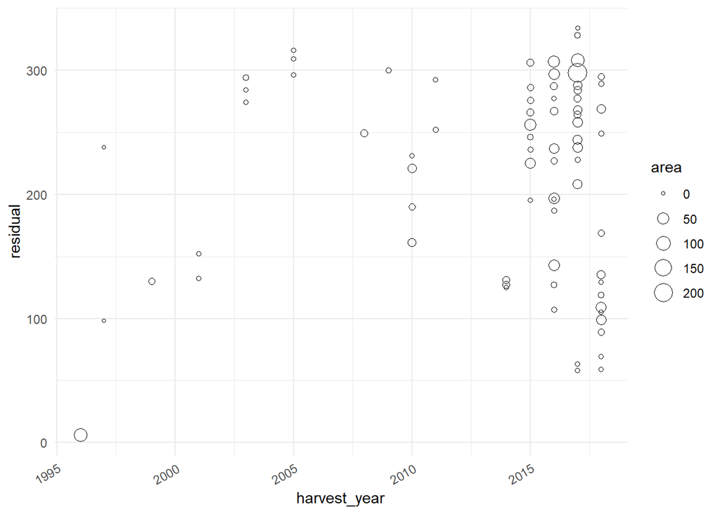

```r
dbGetQuery(db,'
  select harvest_year, proj_age_1-(2017-harvest_year) residual, sum(cflb_fact) area
    from tsa43_res
    where
      harvest_year > ref_year and
      proj_age_1-(2017-harvest_year) is not null
    group by 1,2 order by 1,2;
') %>%
ggplot(aes(harvest_year, residual)) + geom_point(shape=1, aes(size=area)) + gg_theme
```

```r
dbGetQuery(db,'
  select
    proj_age_1-(2017-harvest_year) residual, sum(included) total,
    sum(cflb_fact) cflb, sum(thlb_fact) thlb
    from tsa43_res
    where
      harvest_year > ref_year and
      proj_age_1-(2017-harvest_year) > 10
    group by 1 order by 1;
') %>%
mutate(residualCls = cut(residual, seq(0, 340, 20))) %>%
select(-residual) %>%
group_by(residualCls) %>% summarise_if(is.numeric, sum) %>%
bind_rows(
    summarise_if(., is.numeric, sum, na.rm=T)
) %>%
kable() %>%
    row_spec(16, bold=T)
```

| residualCls | total | cflb | thlb |
| --- | --- | --- | --- |
| (40,60] | 4 | 4 | 2 |
| (60,80] | 4 | 4 | 0 |
| (80,100] | 40 | 39 | 38 |
| (100,120] | 51 | 50 | 39 |
| (120,140] | 60 | 59 | 53 |
| (140,160] | 46 | 45 | 41 |
| (160,180] | 28 | 28 | 0 |
| (180,200] | 61 | 60 | 9 |
| (200,220] | 30 | 30 | 29 |
| (220,240] | 147 | 141 | 121 |
| (240,260] | 143 | 138 | 126 |
| (260,280] | 99 | 98 | 92 |
| (280,300] | 342 | 334 | 286 |
| (300,320] | 153 | 151 | 136 |
| (320,340] | 5 | 5 | 5 |
|  | 1,213 | 1,186 | 977 |

Create a new model age that is updated for harvest depletions. This age will be exported for use in SELES.

```sql
alter table tsa43_dataprep
  add column age integer;
```

```sql
update tsa43_dataprep dp set
  age = 2017 - harvest_year
from tsa43_res res
where
  harvest_year > ref_year and
  proj_age_1 - (2017 - harvest_year) > 10 and
  dp.gr_skey = res.gr_skey;
```

# 5 Biodiversity

**Data Package Section 5.14.1 Seral stage requirements**

Two seral constraints are applied for biodiversity: ‘old’ and ‘mature plus old’. Constraints were evaluated and constructed in the spreadsheet `srmpBiodiversity.xlsx`.

```sql
alter table tsa43_dataprep
  add column biod_old_lb text,
  add column biod_old_con text,
  add column biod_mat_lb text,
  add column biod_mat_con text;
```

## 5.1 Old Seral Retention

I confirmed that the Provincial Non-Spatial Old Growth Order matched the ‘old’ targets in the SRMP Order. They matched exactly so I created a constraint for the whole TSA using the NSOG Order targets just using NDT/BEC/BEO. Laura Bolster noted that the OGMA do not meet the full old targets so the NSOG Order should be applied in addition to OGMA.

Classify the land base under the ‘old’ seral constraint.

```sql
update tsa43_dataprep dp set
  biod_old_lb = case
    when bec_ndt = 'NDT1' and bec_zone = 'CWH' and lu_beo = 'Intermediate' then '1_CWH_I'
    when bec_ndt = 'NDT1' and bec_zone = 'ESSF' and lu_beo = 'Intermediate' then '1_ESSF_I'
    when bec_ndt = 'NDT1' and bec_zone = 'ESSF' and lu_beo = 'Low' then '1_ESSF_L'
    when bec_ndt = 'NDT1' and bec_zone = 'ICH' and lu_beo = 'Intermediate' then '1_ICH_I'
    when bec_ndt = 'NDT1' and bec_zone = 'ICH' and lu_beo = 'Low' then '1_ICH_L'
    when bec_ndt = 'NDT1' and bec_zone = 'MH' and lu_beo = 'High' then '1_MH_H'
    when bec_ndt = 'NDT1' and bec_zone = 'MH' and lu_beo = 'Intermediate' then '1_MH_I'
    when bec_ndt = 'NDT1' and bec_zone = 'MH' and lu_beo = 'Low' then '1_MH_L'
    when bec_ndt = 'NDT2' and bec_zone = 'CWH' and lu_beo = 'High' then '2_CWH_H'
    when bec_ndt = 'NDT2' and bec_zone = 'CWH' and lu_beo = 'Intermediate' then '2_CWH_I'
    when bec_ndt = 'NDT2' and bec_zone = 'CWH' and lu_beo = 'Low' then '2_CWH_L'
    when bec_ndt = 'NDT2' and bec_zone = 'ICH' and lu_beo = 'High' then '2_ICH_H'
    when bec_ndt = 'NDT2' and bec_zone = 'ICH' and lu_beo = 'Intermediate' then '2_ICH_I'
    when bec_ndt = 'NDT2' and bec_zone = 'ICH' and lu_beo = 'Low' then '2_ICH_L'
    when bec_ndt = 'NDT3' and bec_zone = 'ESSF' and lu_beo = 'Intermediate' then '3_ESSF_I'
    when bec_ndt = 'NDT3' and bec_zone = 'ESSF' and lu_beo = 'Low' then '3_ESSF_L'
    when bec_ndt = 'NDT3' and bec_zone = 'SBS' and lu_beo = 'Intermediate' then '3_SBS_I'
    when bec_ndt = 'NDT3' and bec_zone = 'SBS' and lu_beo = 'Low' then '3_SBS_L'
  end
from tsa43_res res
where
  dp.cflb_fact > 0 and
  dp.gr_skey = res.gr_skey;
```

Assign the constraint to be applied.

```sql
update tsa43_dataprep dp set
  biod_old_con = case
    when bec_ndt = 'NDT1' and bec_zone = 'CWH' and lu_beo = 'Intermediate' then 'a250p13'
    when bec_ndt = 'NDT1' and bec_zone = 'ESSF' and lu_beo = 'Intermediate' then 'a250p19'
    when bec_ndt = 'NDT1' and bec_zone = 'ESSF' and lu_beo = 'Low' then 'a250p19'
    when bec_ndt = 'NDT1' and bec_zone = 'ICH' and lu_beo = 'Intermediate' then 'a250p13'
    when bec_ndt = 'NDT1' and bec_zone = 'ICH' and lu_beo = 'Low' then 'a250p13'
    when bec_ndt = 'NDT1' and bec_zone = 'MH' and lu_beo = 'High' then 'a250p28'
    when bec_ndt = 'NDT1' and bec_zone = 'MH' and lu_beo = 'Intermediate' then 'a250p19'
    when bec_ndt = 'NDT1' and bec_zone = 'MH' and lu_beo = 'Low' then 'a250p19'
    when bec_ndt = 'NDT2' and bec_zone = 'CWH' and lu_beo = 'High' then 'a250p13'
    when bec_ndt = 'NDT2' and bec_zone = 'CWH' and lu_beo = 'Intermediate' then 'a250p9'
    when bec_ndt = 'NDT2' and bec_zone = 'CWH' and lu_beo = 'Low' then 'a250p9'
    when bec_ndt = 'NDT2' and bec_zone = 'ICH' and lu_beo = 'High' then 'a250p13'
    when bec_ndt = 'NDT2' and bec_zone = 'ICH' and lu_beo = 'Intermediate' then 'a250p9'
    when bec_ndt = 'NDT2' and bec_zone = 'ICH' and lu_beo = 'Low' then 'a250p9'
    when bec_ndt = 'NDT3' and bec_zone = 'ESSF' and lu_beo = 'Intermediate' then 'a140p14'
    when bec_ndt = 'NDT3' and bec_zone = 'ESSF' and lu_beo = 'Low' then 'a140p14'
    when bec_ndt = 'NDT3' and bec_zone = 'SBS' and lu_beo = 'Intermediate' then 'a140p11'
    when bec_ndt = 'NDT3' and bec_zone = 'SBS' and lu_beo = 'Low' then 'a140p11'
  end
from tsa43_res res
where
  dp.cflb_fact > 0 and
  dp.gr_skey = res.gr_skey;
```

Summarize the area covered by the constraint.

- The current netdown has a CFLB of 557,353 ha
- Not all of the BEC were covered by the Old Growth Order so there is 4577 ha of CFLB with no constraint

```r
dbGetQuery(db,'
  select biod_old_lb, biod_old_con, sum(cflb_fact) cflb, sum(cflb_fact*thlb_fact) thlb
  from tsa43_dataprep
  where biod_old_lb is not null
  group by 1,2 order by 1,2;
') %>%
bind_rows(summarise_if(., is.numeric, sum, na.rm=T)) %>%
rename('Land Base' = biod_old_lb, 'Constraint' = biod_old_con) %>%
kable() %>%
  row_spec(19, bold=T)
```

| Land Base | Constraint | cflb | thlb |
| --- | --- | --- | --- |
| 1_CWH_I | a250p13 | 7,166 | 2,009 |
| 1_ESSF_I | a250p19 | 35,608 | 508 |
| 1_ESSF_L | a250p19 | 58,328 | 6 |
| 1_ICH_I | a250p13 | 74,875 | 41,327 |
| 1_ICH_L | a250p13 | 54,861 | 25,763 |
| 1_MH_H | a250p28 | 3,141 | 961 |
| 1_MH_I | a250p19 | 36,868 | 17,612 |
| 1_MH_L | a250p19 | 23,142 | 13,403 |
| 2_CWH_H | a250p13 | 4,738 | 3,131 |
| 2_CWH_I | a250p9 | 412 | 210 |
| 2_CWH_L | a250p9 | 7,628 | 4,502 |
| 2_ICH_H | a250p13 | 7,990 | 2,594 |
| 2_ICH_I | a250p9 | 91,909 | 43,160 |
| 2_ICH_L | a250p9 | 89,629 | 45,250 |
| 3_ESSF_I | a140p14 | 17,243 | 6,040 |
| 3_ESSF_L | a140p14 | 10,188 | 2,937 |
| 3_SBS_I | a140p11 | 18,453 | 1,680 |
| 3_SBS_L | a140p11 | 10,597 | 0 |
|  |  | 552,776 | 211,092 |

Confirm the area not covered by the Old Growth Order.

- It is all high elevation BEC in NDT 5
- Interesting that there is some THLB in the Mountain Hemlock

```r
dbGetQuery(db,'
  select bec_ndt, bec_zone, lu_beo, sum(dp.cflb_fact) cflb, sum(dp.cflb_fact*dp.thlb_fact) thlb
  from tsa43_dataprep dp
  left join tsa43_res res
  on dp.gr_skey = res.gr_skey
  where biod_old_lb is null and dp.cflb_fact > 0
  group by 1,2,3 order by 1,2,3;
') %>%
bind_rows(summarise_if(., is.numeric, sum, na.rm=T)) %>%
kable() %>%
  row_spec(8, bold=T)
```

| bec_ndt | bec_zone | lu_beo | cflb | thlb |
| --- | --- | --- | --- | --- |
| NDT5 | CMA | Intermediate | 36 | 0 |
| NDT5 | CMA | Low | 10 | 0 |
| NDT5 | ESSF | Intermediate | 1,207 | 0 |
| NDT5 | ESSF | Low | 1,213 | 0 |
| NDT5 | MH | High | 5 | 3 |
| NDT5 | MH | Intermediate | 1,755 | 542 |
| NDT5 | MH | Low | 351 | 159 |
|  |  |  | 4,577 | 704 |

Map the extent of the constraint.

```r
boidOldMapData <- st_read(db, query='
  select biod_old_lb, biod_old_con, st_union(wkb_geometry)
  from tsa43_dataprep
  where biod_old_lb is not null
  group by 1,2;
')
tmap_arrange(
  tm_shape(boidOldMapData) +
    tm_fill('biod_old_lb', title='Old Land Base') +
    tm_layout(frame = FALSE) + bnd,

  tm_shape(boidOldMapData) +
    tm_fill('biod_old_con', title='Old Constraints') +
    tm_layout(frame = FALSE) + bnd
)
```

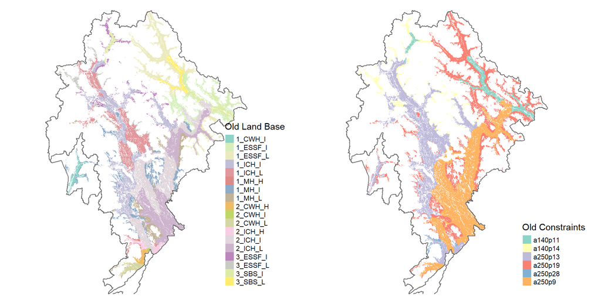

## 5.2 Mature Plus Old Seral Retention

The ‘mature plus old’ targets from the SRMP did not match up well with the LU/BEC within the SRMP area from the resultant data. Laura Bolster confirmed that it may not have been comprehensive at the time and that BEC mapping may have been revised since. She recommended that the constraints are only applied where matches occur and the remaining area is free of ‘mature plus old’ constraints.

- All ICH mc 1a combined with normal ICH mc 1 (Brown Bear 66ha, Kinskuch 14,165ha, Tchitin 4,189ha)

Classify the land base under the ‘mature plus old’ constraint.

```sql
update tsa43_dataprep dp set
  biod_mat_lb = case
    when lu_name = 'Bear' and bgc_label = 'CWH wm' then 'Bear_CWHwm'
    when lu_name = 'Bear' and bgc_label = 'MH  mm 2' then 'Bear_MHmm2'
    when lu_name = 'Bear' and bgc_label = 'MH  mmp' then 'Bear_MHmmp'
    when lu_name = 'Bowser' and bgc_label = 'ICH vc' then 'Bowser_ICHvc'
    when lu_name = 'Brown Bear' and bgc_label in ('ICH mc 1','ICH mc 1a') then 'BrownBear_ICHmc1'
    when lu_name = 'Cambria Icefield' and bgc_label = 'MH  mm 2' then 'CambriaIcefield_MHmm2'
    when lu_name = 'Kinskuch' and bgc_label in ('ICH mc 1','ICH mc 1a') then 'Kinskuch_ICHmc1'
    when lu_name = 'Kinskuch' and bgc_label = 'ICH vc' then 'Kinskuch_ICHvc'
    when lu_name = 'Kwinamuck' and bgc_label = 'CWH ws 2' then 'Kwinamuck_CWHws2'
    when lu_name = 'Kwinamuck' and bgc_label = 'MH  mm 2' then 'Kwinamuck_MHmm2'
    when lu_name = 'Madely' and bgc_label = 'ICH mc 1' then 'Madely_ICHmc1'
    when lu_name = 'Madely' and bgc_label = 'ICH vc' then 'Madely_ICHvc'
    when lu_name = 'Tchitin' and bgc_label = 'CWH ws 2' then 'Tchitin_CWHws2'
    when lu_name = 'Tchitin' and bgc_label in ('ICH mc 1','ICH mc 1a') then 'Tchitin_ICHmc1'
    when lu_name = 'Tchitin' and bgc_label = 'MH  mm 2' then 'Tchitin_MHmm2'
    when lu_name = 'Tintina' and bgc_label = 'ICH mc 1' then 'Tintina_ICHmc1'
    when lu_name = 'Tintina' and bgc_label = 'ICH vc' then 'Tintina_ICHvc'
    when lu_name = 'White' and bgc_label = 'ICH mc 1' then 'White_ICHmc1'
    when lu_name = 'White' and bgc_label = 'ICH vc' then 'White_ICHvc'
    when lu_name = 'White' and bgc_label = 'MH  mm 2' then 'White_MHmm2'
    when lu_name = 'Wildfire' and bgc_label = 'ICH vc' then 'Wildfire_ICHvc'
  end
from tsa43_res res
where
  dp.cflb_fact > 0 and
  rmp_strgc_name = 'Nass South Sustainable Resource Management Plan' and
  dp.gr_skey = res.gr_skey;
```

Assign the constraint to be applied.

```sql
update tsa43_dataprep dp set
  biod_mat_con = case
    when lu_name = 'Bear' and bgc_label = 'CWH wm' then 'a80p36'
    when lu_name = 'Bear' and bgc_label = 'MH  mm 2' then 'a120p36'
    when lu_name = 'Bear' and bgc_label = 'MH  mmp' then 'a120p22'
    when lu_name = 'Bowser' and bgc_label = 'ICH vc' then 'a100p17'
    when lu_name = 'Brown Bear' and bgc_label  in ('ICH mc 1','ICH mc 1a') then 'a100p15'
    when lu_name = 'Cambria Icefield' and bgc_label = 'MH  mm 2' then 'a120p19'
    when lu_name = 'Kinskuch' and bgc_label in ('ICH mc 1','ICH mc 1a') then 'a100p31'
    when lu_name = 'Kinskuch' and bgc_label = 'ICH vc' then 'a100p34'
    when lu_name = 'Kwinamuck' and bgc_label = 'CWH ws 2' then 'a80p17'
    when lu_name = 'Kwinamuck' and bgc_label = 'MH  mm 2' then 'a120p19'
    when lu_name = 'Madely' and bgc_label  = 'ICH mc 1' then 'a100p31'
    when lu_name = 'Madely' and bgc_label = 'ICH vc' then 'a100p34'
    when lu_name = 'Tchitin' and bgc_label = 'CWH ws 2' then 'a80p51'
    when lu_name = 'Tchitin' and bgc_label in ('ICH mc 1','ICH mc 1a') then 'a100p46'
    when lu_name = 'Tchitin' and bgc_label = 'MH  mm 2' then 'a120p54'
    when lu_name = 'Tintina' and bgc_label = 'ICH mc 1' then 'a100p15'
    when lu_name = 'Tintina' and bgc_label = 'ICH vc' then 'a100p17'
    when lu_name = 'White' and bgc_label = 'ICH mc 1' then 'a100p31'
    when lu_name = 'White' and bgc_label = 'ICH vc' then 'a100p34'
    when lu_name = 'White' and bgc_label = 'MH  mm 2' then 'a120p36'
    when lu_name = 'Wildfire' and bgc_label = 'ICH vc' then 'a100p34'
  end
from tsa43_res res
where
  dp.cflb_fact > 0 and
  rmp_strgc_name = 'Nass South Sustainable Resource Management Plan' and
  dp.gr_skey = res.gr_skey;
```

Summarize the area covered by the constraint.

```r
dbGetQuery(db,'
  select biod_mat_lb, biod_mat_con, sum(cflb_fact) cflb, sum(cflb_fact*thlb_fact) thlb
  from tsa43_dataprep
  where biod_mat_lb is not null
  group by 1,2 order by 1,2;
') %>%
bind_rows(summarise_if(., is.numeric, sum, na.rm=T)) %>%
rename('Land Base' = biod_mat_lb, 'Constraint' = biod_mat_con) %>%
kable() %>%
  row_spec(22, bold=T)
```

| Land Base | Constraint | cflb | thlb |
| --- | --- | --- | --- |
| Bear_CWHwm | a80p36 | 7,164 | 2,009 |
| Bear_MHmm2 | a120p36 | 594 | 127 |
| Bear_MHmmp | a120p22 | 1,558 | 439 |
| Bowser_ICHvc | a100p17 | 1,151 | 13 |
| BrownBear_ICHmc1 | a100p15 | 52,349 | 30,582 |
| CambriaIcefield_MHmm2 | a120p19 | 357 | 134 |
| Kinskuch_ICHmc1 | a100p31 | 15,095 | 6,542 |
| Kinskuch_ICHvc | a100p34 | 4,098 | 1,780 |
| Kwinamuck_CWHws2 | a80p17 | 7,627 | 4,501 |
| Kwinamuck_MHmm2 | a120p19 | 1,182 | 471 |
| Madely_ICHmc1 | a100p31 | 26,778 | 14,349 |
| Madely_ICHvc | a100p34 | 3,241 | 1,300 |
| Tchitin_CWHws2 | a80p51 | 4,738 | 3,130 |
| Tchitin_ICHmc1 | a100p46 | 4,189 | 1,378 |
| Tchitin_MHmm2 | a120p54 | 2,563 | 772 |
| Tintina_ICHmc1 | a100p15 | 817 | 466 |
| Tintina_ICHvc | a100p17 | 20,150 | 5,676 |
| White_ICHmc1 | a100p31 | 7,044 | 2,921 |
| White_ICHvc | a100p34 | 24,925 | 11,687 |
| White_MHmm2 | a120p36 | 6,965 | 3,613 |
| Wildfire_ICHvc | a100p34 | 3,481 | 1,912 |
|  |  | 196,067 | 93,803 |

Map the extent of the constraint.

```r
boidMatMapData <- st_read(db, query='
  select biod_mat_lb, biod_mat_con, st_union(wkb_geometry)
  from tsa43_dataprep
  where biod_mat_lb is not null
  group by 1,2;
')
tmap_arrange(
  tm_shape(boidMatMapData) +
    tm_fill('biod_mat_lb', title='Mature Land Base') +
    tm_layout(frame = FALSE, legend.outside = TRUE) + srmp + bnd,

  tm_shape(boidMatMapData) +
    tm_fill('biod_mat_con', title='Mature Constraints') +
    tm_layout(frame = FALSE, legend.outside = TRUE) + srmp + bnd
)
```

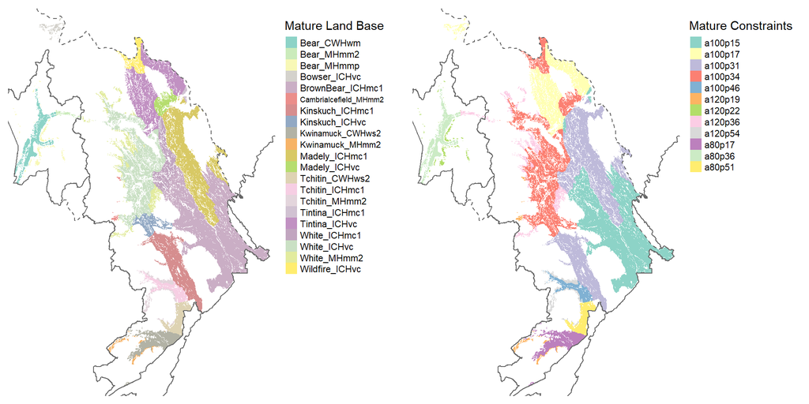

# 6 Adjacency

**Data Package Section 6.3.1**

The SRMP includes objectives for adjacency, green-up and patch size distribution but, due to modelling limitations, these will all be respresented by a general disturbance constraint. In the old days this was called the Integreated Resources Management (IRM) constraint so I will continue to use this term for my scripting.

- The land base is the THLB by landscape unit
- The constraint is no more than 35% below 3m height

Height tables were provided with the Provincial TIPSY output from Dave Waddel.

```sql
alter table tsa43_dataprep
  add column irm_lb text,
  add column irm_con numeric;
```

The land base is simply the LU name assigned within the THLB. There is only one constraint applied so a value of 1 is assigned to all the THLB area.

```sql
update tsa43_dataprep dp set
  irm_lb = res.lu_name,
  irm_con = 1
from tsa43_res res
where
  dp.thlb_fact > 0 and dp.cflb_fact > 0
  and dp.gr_skey = res.gr_skey;
```

Do any area summary to make sure the THLB is covered.

- The current netdown has a THLB of 211,796 ha so this is a match.

```r
dbGetQuery(db,'
  select irm_lb, sum(cflb_fact) cflb, sum(cflb_fact*thlb_fact) thlb
  from tsa43_dataprep
  where irm_lb is not null
  group by 1 order by 1;
') %>%
bind_rows(summarise_if(., is.numeric, sum, na.rm=T)) %>%
rename('Landscape Unit' = irm_lb) %>%
kable() %>%
  row_spec(17, bold=T)
```

| Landscape Unit | cflb | thlb |
| --- | --- | --- |
| Bear | 4,390 | 4,019 |
| Bowser | 4,081 | 4,008 |
| Brown Bear | 39,557 | 36,866 |
| Cambria Icefield | 172 | 157 |
| Craven | 5,426 | 5,253 |
| Kinskuch | 12,406 | 11,379 |
| Kwinamuck | 5,518 | 4,996 |
| Madely | 39,492 | 37,675 |
| Nass River Kalum | 1,553 | 1,406 |
| Oweegee | 7,676 | 7,479 |
| Sallysout | 19,905 | 19,205 |
| Taylor - Damdochax | 14,685 | 14,329 |
| Tchitin | 5,809 | 5,283 |
| Tintina | 19,941 | 19,309 |
| White | 19,305 | 18,223 |
| Wildfire | 22,907 | 22,211 |
|  | 222,822 | 211,796 |

It is not really needed but might as well map the extent of the constraint.

- It is clear tha Upper Nass is excluded from the THLB

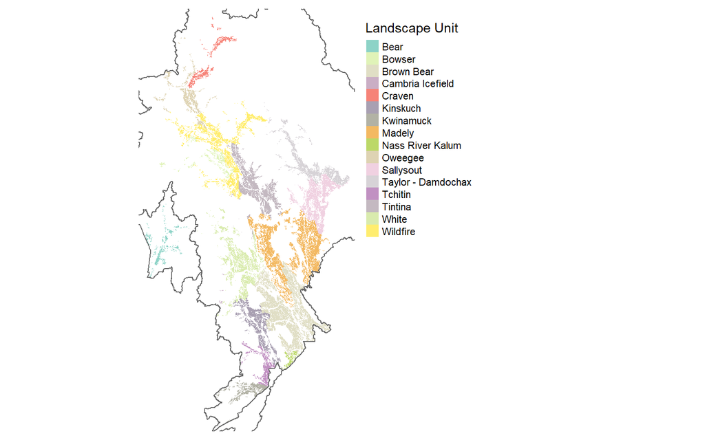

```r
irmMapData <- st_read(db, query='
  select irm_lb, st_union(wkb_geometry)
  from tsa43_dataprep
  where irm_lb is not null
  group by 1;
')
tm_shape(irmMapData) +
  tm_fill('irm_lb', title = 'Landscape Unit') +
  tm_layout(frame = FALSE, legend.outside = TRUE) + bnd
```

Just because the data are there and we can…

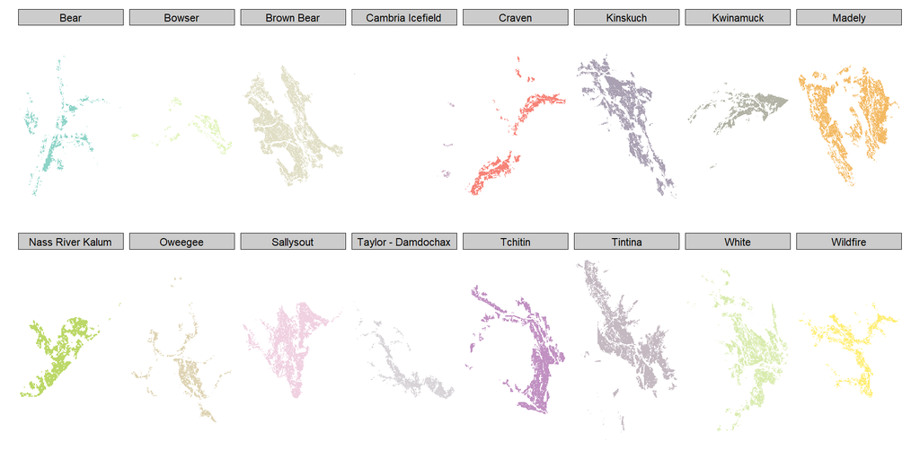

```r
tm_shape(irmMapData) +
  tm_fill('irm_lb') +
  tm_layout(frame = FALSE, legend.show = F) +
  tm_facets(by = 'irm_lb')
```